# Anke Cajar:Borrowing Strength in IAT: Faking Subject

## 4.3 Partial pooling

These are fixed effects plus conditional modes (aka BLUPs) for 19 “faking” subjects.

```r
coef_mm <-
  coef(m_cpx)[["Subj"]] |>
  select(GM=1, Switch=2, Time=3, Block=4) |>
  add_column(Subj = pull(coef_ws, "Subj"),
             Pooling = "Partial") |>
  relocate(Subj) |>
  as_tibble()

coef_mm
```

```
# A tibble: 19 × 6
   Subj     GM Switch     Time    Block Pooling
   <chr> <dbl>  <dbl>    <dbl>    <dbl> <chr>
 1 S007   1.50  0.158  0.0722  -0.0134  Partial
 2 S008   1.25  0.218  0.147   -0.0146  Partial
 3 S015   1.60  0.146  0.0935  -0.0327  Partial
 4 S020   1.59  0.188 -0.0108   0.145   Partial
 5 S034   1.44  0.184  0.186   -0.0635  Partial
 6 S043   1.36  0.176  0.132   -0.00756 Partial
 7 S053   1.59  0.107  0.0749   0.00966 Partial
 8 S064   1.18  0.159  0.252   -0.104   Partial
 9 S071   1.47  0.197  0.0596  -0.00299 Partial
10 S073   1.48  0.152  0.0660   0.0206  Partial
11 S087   1.20  0.150 -0.0358   0.0896  Partial
12 S091   1.40  0.152  0.0476  -0.0121  Partial
13 S104   1.53  0.164  0.00917  0.106   Partial
14 S115   1.56  0.163 -0.0350   0.0619  Partial
15 S117   1.23  0.218  0.133   -0.0502  Partial
16 S134   1.40  0.165  0.154   -0.110   Partial
17 S137   1.23  0.219  0.104   -0.0475  Partial
18 S142   1.26  0.200 -0.00260  0.0655  Partial
19 S156   1.46  0.212 -0.0728   0.174   Partial
```

```r
#lattice::splom(~ coef_mm[,2:4])
```

## 4.4 Complete pooling

Here we ignore that data come from different subjects. We treat the data as independent observations; no clustering is assumed. The fixed effects are centers of gravity in the plots.

```r
gravity <- coef(lm(speed ~ 1 + Switch*Time*Block, iat_fake))[1:4]
names(gravity) <- c("GM", "Switch", "Time", "Block")
gravity <- data.frame(as.list(gravity))
gravity$Subj <- "All"
gravity$Pooling <- "Complete"
gravity <- gravity[,c(5,1:4,6)]
```

## 4.5 Plots

### 4.5.1 SPLOM

Here we compare within-subject estimates (no pooling) and BLUPs (partial pooling).

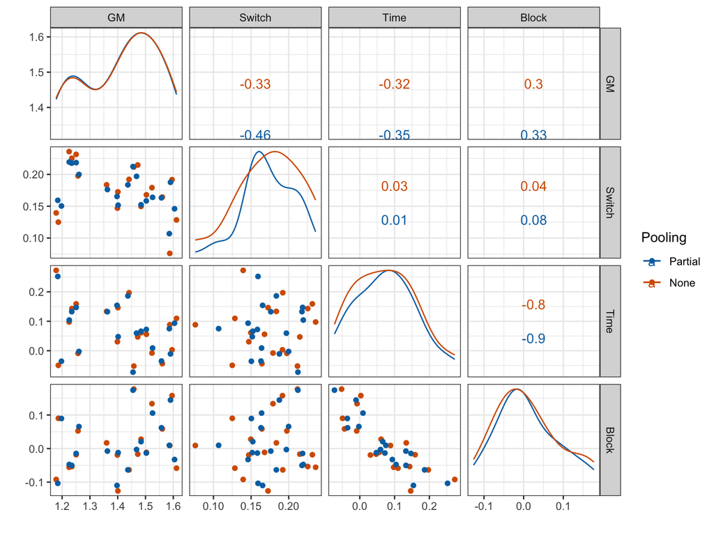

```r
# Combine no-pooling and partial pooling estimates
coef_ws_mm <- bind_rows(coef_ws, coef_mm)

coef_ws_mm |>
  mutate(Pooling = fct_rev(Pooling)) |>
  ggscatmat(columns=2:5, color="Pooling") +
  scale_color_manual("Pooling", values=cbPalette) +
  xlab("") + ylab("") + theme_bw()
```

- There is a moderate negative correlation between `GM` and `Switch` effect (i.e., -.33 with no-pooling and -.46 with partial pooling; the corresponding CP was -.39).
- There is a strong negative correlation between `Time` and `Block` effects, irrespective of no-pooling (-0.8) or partial-pooling (-0.9) of effects. The corresponding CP was -.86.

### 4.5.2 Setup

The following code chunks are taken directly from Tristan Mahr’s blog.

```r
# Helper function to make a data-frame of ellipse points that
# includes the level as a column
make_ellipse <- function(cov_mat, center, level) {
  ellipse(cov_mat, centre = center, level = level) %>%
    as.data.frame() %>%
    add_column(level = level) %>%
    as_tibble()
}

# Contour lines
levels <- c(.1, .3, .5, .7, .9)

# Strip off some details so that just the useful part is printed
cov_mat <- VarCorr(m_cpx)[["Subj"]]
attr(cov_mat, "stddev") <- NULL
attr(cov_mat, "correlation") <- NULL

# Add complete pooling to ws- and mm-collection of estimates
coef_all <- rbind(gravity, coef_ws_mm)
```

### 4.5.3 `GM` over `Switch` costs

We plot individual difference in switch costs over overall mean response speed.

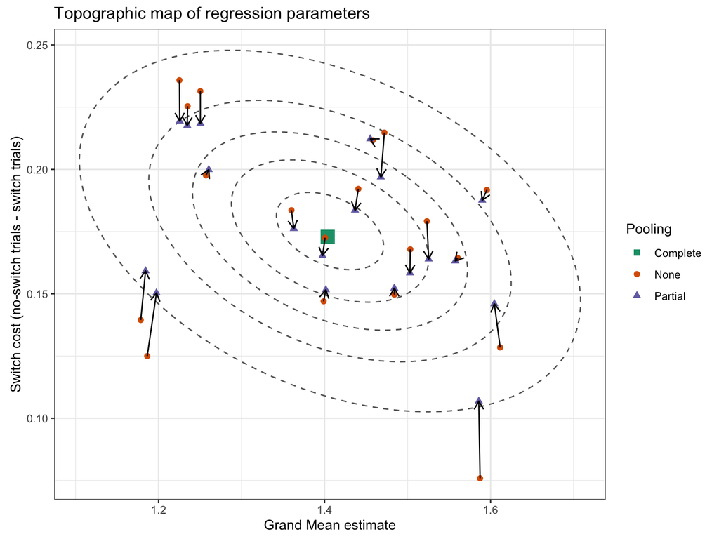

```r
center12 <- fixef(m_cpx)[1:2]
cov_mat12 <- cov_mat[1:2, 1:2]

# Create an ellipse dataframe for each of the levels defined
# above and combine them
df_ellipse12 <- levels %>%
  lapply(
    function(x) make_ellipse(cov_mat12, center12, level = x)
  ) %>%
  bind_rows() %>%
  rename(GM = `(Intercept)`, Switch = "sw")

ggplot(coef_all) +
  aes(x = GM, y = Switch, color = Pooling, shape = Pooling) +
  # Draw contour lines from the distribution of effects
  geom_path(
    aes(group = level, color = NULL, shape = NULL),
    data = df_ellipse12,
    linetype = "dashed",
    color = "grey40"
  ) +
  geom_point(
    aes(shape = Pooling),
    data = gravity,
    size = 5,
    show.legend = FALSE
  ) +
  geom_point(size = 2) +
  geom_path(
    aes(group = Subj, color = NULL),
    arrow = arrow(length = unit(.02, "npc")),
    show.legend = FALSE
  ) +
  theme(
    legend.position = "bottom",
    legend.justification = "right"
  ) +
  ggtitle("Topographic map of regression parameters") +
  xlab("Grand Mean estimate") +
  ylab("Switch cost (no-switch trials - switch trials)") +
  scale_color_brewer(palette = "Dark2") +
  scale_shape_manual(values = c(15:18)) +
  theme_bw() + coord_fixed(ratio=3)
```

We embellished the plot with ellipses to show that even if arrows are not pointing directly at the center of gravity, almost all of them move the conditional mean closer to it when judging their positions with the contour lines.

#### 4.5.3.1 `Block` effect over `Time` effect

We plot individual difference in slow-down due to incompatibility of required responses over slow-down from baseline to retest. The correlation is negative, that is slowing down reduces the incompatibility effect.

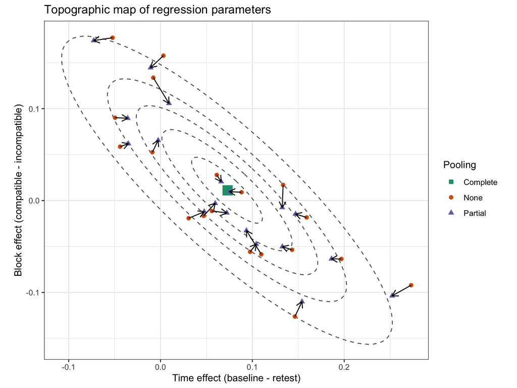

```r
center34 <- fixef(m_cpx)[3:4]
cov_mat34 <- cov_mat[3:4, 3:4]

# Create an ellipse dataframe for each of the levels defined
# above and combine them
df_ellipse34 <- levels %>%
  lapply(
    function(x) make_ellipse(cov_mat34, center34, level = x)
  ) %>%
  bind_rows() %>%
  rename(Time = tm, Block = bl)

ggplot(coef_all) +
  aes(x = Time, y = Block, color = Pooling, shape = Pooling) +
  # Draw contour lines from the distribution of effects
  geom_path(
    aes(group = level, color = NULL, shape = NULL),
    data = df_ellipse34,
    linetype = "dashed",
    color = "grey40"
  ) +
  geom_point(
    aes(shape = Pooling),
    data = gravity,
    size = 5,
    show.legend = FALSE
  ) +
  geom_point(size = 2) +
  geom_path(
    aes(group = Subj, color = NULL),
    arrow = arrow(length = unit(.02, "npc")),
    show.legend = FALSE
  ) +
  theme(
    legend.position = "bottom",
    legend.justification = "right"
  ) +
  ggtitle("Topographic map of regression parameters") +
  xlab("Time effect (baseline - retest)") +
  ylab("Block effect (compatible - incompatible)") +
  scale_color_brewer(palette = "Dark2") +
  scale_shape_manual(values = c(15:18)) +
  theme_bw() + coord_fixed(ratio=1)
```

A positive `Time` effect means increased speed was higher at baseline than retest. This is not implausible for subjects in the “faking” group who were instructed to slow down in speed during retest. Negative values mean that retest speed was higher than baseline speed – either because subjects did not follow instructions or practice-related improvement was larger than faked slow down.

A positive `Block` effect means that there is a large difference in speed between compatible and incompatible blocks of trials. Subjects who slowed down much during retests compared to baseline block (i.e., those with very positive `Time` effects) show small `Block` effects. In other words, subjects who acted as instructed and slowed down during retest reduced their incompatibility cost in response speed.

The corresponding plot for the non-fake group does not show this dependency between `GM` and `Switch` costs or `Time` and `Block` effects. Recall that CPs could be forced to zero without loss of goodness of fit, but the four VCs contributed to the goodness of fit, that is there were reliable individual differences associated with them. The corresponding last plot is shown here:

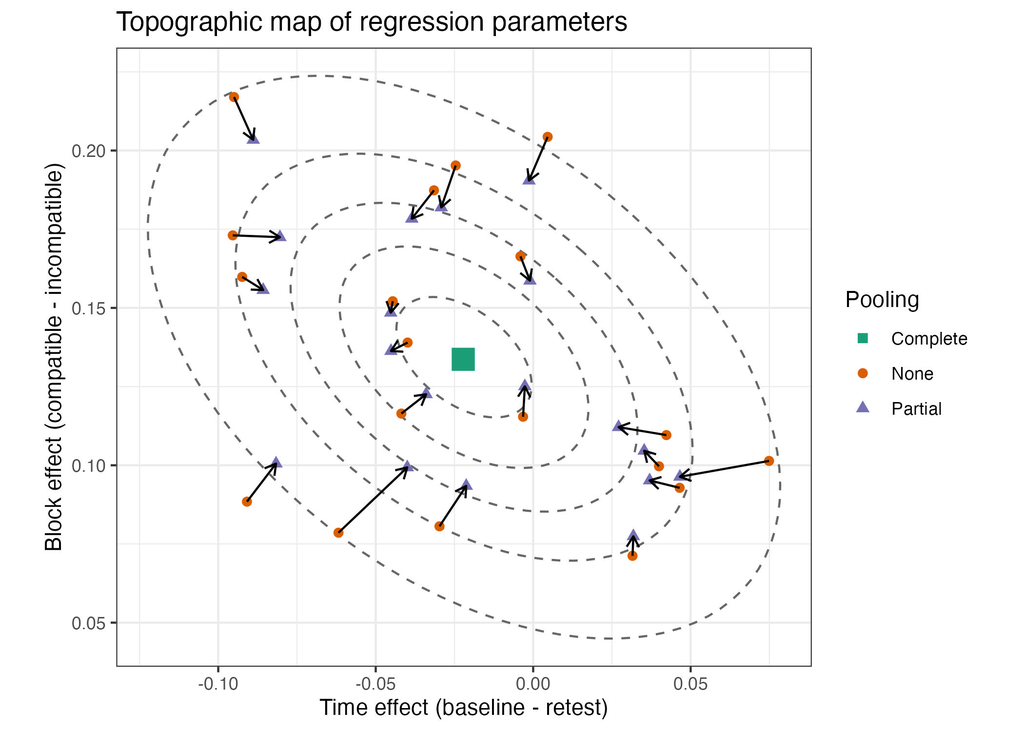

# 5 Appendix